# spatial activities ver.2

Mikah Nelson

2023-11-03

## Script Rundown

### Purpose

Determine how experience in everyday activities affects spatial ability, activity experience, looking closely at video game experience. Small scale spatial tasks include the Mental Rotation Task - Shepard and Metzler (MRT), Paper Folding, and Object Assembly. Lastly we look at large scale tasks such as immersive Virtual Reality paradigms such as Dual Solutions Paradigm (DSP) using absolute pointing error and wayfinding efficiency, and a Maze task; a desktop task called Virtual SILCton measured in absolute pointing error within and between routes calculated in z-scores, and a desktop Route Learning task. Questionaires measuring everyday experience and general intelligence included here are the SoCal Spatial Activities Questionaire (SoCalSAQ), a video game experience questionnaire, and Raven’s Progressive Matrices (RPM).

### Packages

```r
#clean environment
rm(list = ls())

#load packages
library(pacman)
p_load(dplyr, tidyverse, apaTables, ggplot2, correlation, psych, ppcor, apaTables, xtable)

setwd("/Users/mikah/Desktop/Rstudiodata/hegarty data")
df <- read.csv("spatial activities paper data - activity.csv")
```

### Descriptive Statistics

Set my working directory, ran mean and sds, and ran histograms.

```r
#Overall summary
colnames(df)
```

```
##  [1] "pid"            "DSPabs"         "DSPineff"       "mazeAbs"
##  [5] "mazeGraphIneff" "paperFold"      "ravens"         "route"
##  [9] "nav"            "game"           "creat"          "fit"
## [13] "tech"           "vge"            "objectas"       "mrtCorr"
## [17] "mrtRT"          "SILCwithinabs"  "SILCbetweenabs"
```

```r
numeric_cols <- df[sapply(df, is.numeric)]

# Calculate the column means for numeric columns
means <- colMeans(numeric_cols, na.rm = TRUE)

sds <- apply(numeric_cols, 2, sd, na.rm = TRUE)


# Create a new dataframe to store the means and standard deviations
summary_df <- data.frame(Mean = means, SD = sds)

# Print the resulting summary dataframe
print(summary_df)
```

```
##                        Mean         SD
## DSPabs         75.713854749 20.0067923
## DSPineff        1.932090395  0.5151419
## mazeAbs        56.298353659 25.6268446
## mazeGraphIneff  1.144161491  0.2181844
## paperFold      12.200534759  4.0607649
## ravens         11.645000000  2.7416341
## route           8.682119205  9.6921761
## nav             2.228977528  0.7388104
## game            2.397078652  0.9020068
## creat           2.054494382  0.8772756
## fit             2.508988764  0.7828877
## tech            1.912398876  0.9445590
## objectas       14.510752688  1.6513361
## mrtCorr        -0.002683518  1.0020056
## mrtRT          -0.002777795  1.0019557
## SILCwithinabs   0.003911004  1.0026799
## SILCbetweenabs  0.002950279  1.0031301
```

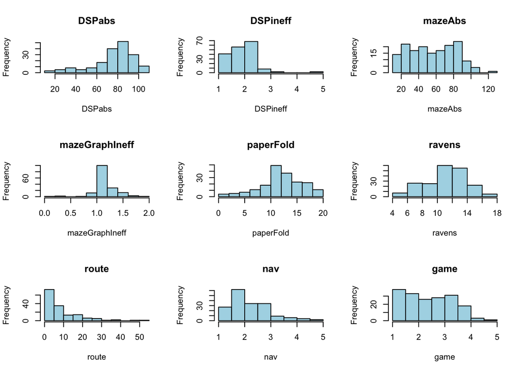

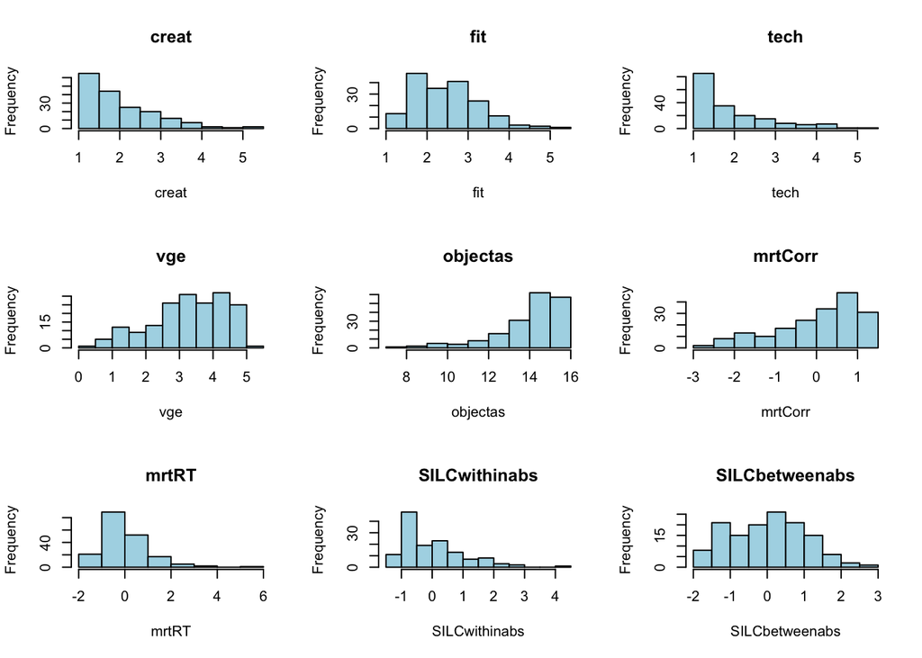

```r
variables_to_plot <- c("DSPabs", "DSPineff", "mazeAbs", "mazeGraphIneff",
                        "paperFold", "ravens", "route", "nav", "game",
                        "creat", "fit", "tech", "vge", "objectas",
                        "mrtCorr", "mrtRT", "SILCwithinabs", "SILCbetweenabs")

 # Convert the specified variables to numeric
for (var in variables_to_plot) {
  df[[var]] <- as.numeric(df[[var]])
}
# Create histograms for each variable
par(mfrow=c(3, 3))  # Adjust the layout of the plots

for (var in variables_to_plot) {
  hist(df[[var]], main=var, xlab=var, col="lightblue", border="black")
}
```

```r
# Reset the layout to default
par(mfrow=c(1, 1))
```

#### Standardization

```r
#create a standardized data frame for scores

# Define the column names to standardize
columns_to_standardize <- c("DSPabs", "DSPineff", "mazeAbs",
                            "mazeGraphIneff", "paperFold", "ravens",
                            "route", "nav", "game", "creat",
                            "fit", "tech", "vge", "objectas")


# Standardize the selected columns
standardized_data <- scale(df[columns_to_standardize], center = TRUE, scale = TRUE)

# Create a new dataframe with the standardized columns and the columns to keep
standardDf <- data.frame(df[setdiff(names(df), columns_to_standardize)], standardized_data)

# Print the resulting standardized dataframe
print(standardDf)
```

```
##            pid     mrtCorr        mrtRT SILCwithinabs SILCbetweenabs
## 1   1001(4001)  1.18710900 -0.257938391   -0.95800734    -1.41178174
## 2         1002  1.30132420  0.771301021   -1.06943627    -1.47989423
## 3         1003 -0.41190374 -0.493238302    2.03070737    -0.09337560
## 4         1004  0.50181783 -0.305865583   -1.02118376    -1.64020473
## 5         1005  0.04495705 -0.353618307   -0.17425596     0.62336932
## 6         1006  0.50181783 -0.823300912   -0.03790921    -0.49000902
## 7         1007  0.27338744 -0.947934636    2.55928820     1.63218479
## 8         1008 -2.23934687 -1.505038247   -0.87621566    -1.20552320
## 9         1009 -1.78248609 -1.120655595    0.66973387    -0.23501638
## 10        1010  0.73024822 -0.624049924   -1.04297022    -1.21033756
## 11        1011 -0.18347335  0.611998366    0.14211676     0.92408734
## 12        1012  0.27338744  0.838578019   -0.51531635     0.01268626
## 13        1013 -1.09719491  0.023692254    0.96687149    -0.17091521
## 14        1014          NA           NA            NA             NA
```

[output cut: 885 more lines]

```r
#reverse score columns
columns_to_reverse_scores <- c("DSPabs", "DSPineff", "mazeAbs",
                            "mazeGraphIneff", "mrtRT", "SILCwithinabs",
                            "SILCbetweenabs", "route")

# Reverse the scores in the selected columns
standardDf[columns_to_reverse_scores] <- -1 * standardDf[columns_to_reverse_scores]
# Step 1: Average DSPabs and DSPineff and save the result as DSP_combined
standardDf$DSP_combined <- (standardDf$DSPabs + standardDf$DSPineff) / 2

# Step 2: Average mazeAbs and mazeGraphIneff and save the result as maze_combined
standardDf$maze_combined <- (standardDf$mazeAbs + standardDf$mazeGraphIneff) / 2

# Step 3: Average pointing errors for SILCton and SILCbetweenabs and save the result as SILC_combined
standardDf$SILC_combined <- rowMeans(standardDf[, c("SILCwithinabs", "SILCbetweenabs")], na.rm = TRUE) / 2

standardDf <- subset(standardDf, select = -c(DSPabs, DSPineff, mazeAbs, mazeGraphIneff, SILCwithinabs, SILCbetweenabs))


colnames(standardDf)
```

```
##  [1] "pid"           "mrtCorr"       "mrtRT"         "paperFold"
##  [5] "ravens"        "route"         "nav"           "game"
##  [9] "creat"         "fit"           "tech"          "vge"
## [13] "objectas"      "DSP_combined"  "maze_combined" "SILC_combined"
```

```r
largeMeans <- rowMeans(standardDf[, c("DSP_combined", "maze_combined", "SILC_combined", "route")], na.rm = TRUE) / 4

smallMeans <- rowMeans(standardDf[, c("mrtCorr","mrtRT", "paperFold",
                                      "objectas")], na.rm = TRUE) / 4
largeVRMeans <- rowMeans(standardDf[, c("DSP_combined", "maze_combined")], na.rm = TRUE) / 2
largeDeskMeans <- rowMeans(standardDf[, c("SILC_combined", "route")], na.rm = TRUE) /2

standardDf$LargeMeans <- largeMeans
standardDf$SmallMeans <- smallMeans
standardDf$LargeDeskMeans <- largeDeskMeans
standardDf$LargeVRMeans <- largeVRMeans

library(dplyr)

# Define the columns to be moved to the end
columns_to_move <- c("nav", "game", "creat", "fit", "tech", "vge")

# Move the specified columns to the end
standardDf <- standardDf %>%
  relocate(all_of(columns_to_move), .after = last_col())

#columns_to_remove <- c("LargeDeskMeans", "LargeVRMeans")

# Remove the specified columns
#standardDf <- subset(standardDf, select = -c(LargeDeskMeans, LargeVRMeans))

# Print the dataframe with the reversed scores
print(standardDf)
```

```
##            pid     mrtCorr        mrtRT   paperFold     ravens       route
## 1   1001(4001)  1.18710900  0.257938391          NA         NA          NA
## 2         1002  1.30132420 -0.771301021  1.61286492  1.9532147  0.89578636
## 3         1003 -0.41190374  0.493238302 -0.91129008 -0.2352611 -1.99314174
## 4         1004  0.50181783  0.305865583  0.81252309  1.9532147  0.89578636
## 5         1005  0.04495705  0.353618307  0.99721736  1.5884687  0.89578636
## 6         1006  0.50181783  0.823300912 -0.17251301  0.4942308  0.58625835
## 7         1007  0.27338744  0.947934636 -0.35720727 -1.3294991 -0.96138170
## 8         1008 -2.23934687  1.505038247          NA  0.1294848  0.68943436
## 9         1009 -1.78248609  1.120655595 -0.23407776 -0.6000071  0.89578636
## 10        1010  0.73024822  0.624049924  1.92068870  0.8589768  0.17355434
## 11        1011 -0.18347335 -0.611998366          NA -0.6000071 -2.09631774
## 12        1012  0.27338744 -0.838578019 -0.41877203  1.5884687  0.79261036
## 13        1013 -1.09719491 -0.023692254 -0.11094825 -0.6000071  0.17355434
## 14        1014          NA           NA          NA         NA          NA
```

[output cut: 885 more lines]

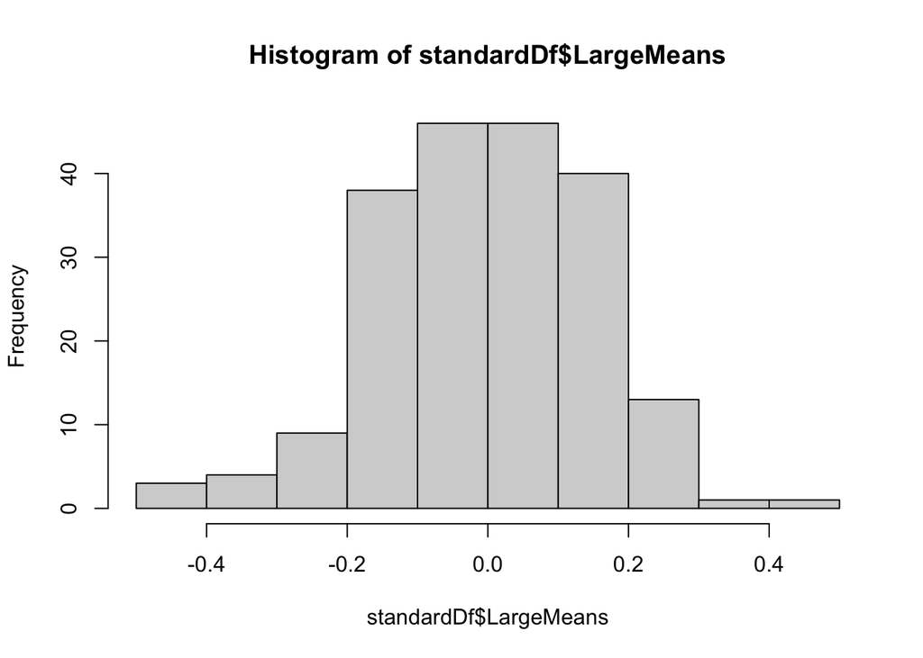

```r
hist(standardDf$LargeMeans)
```

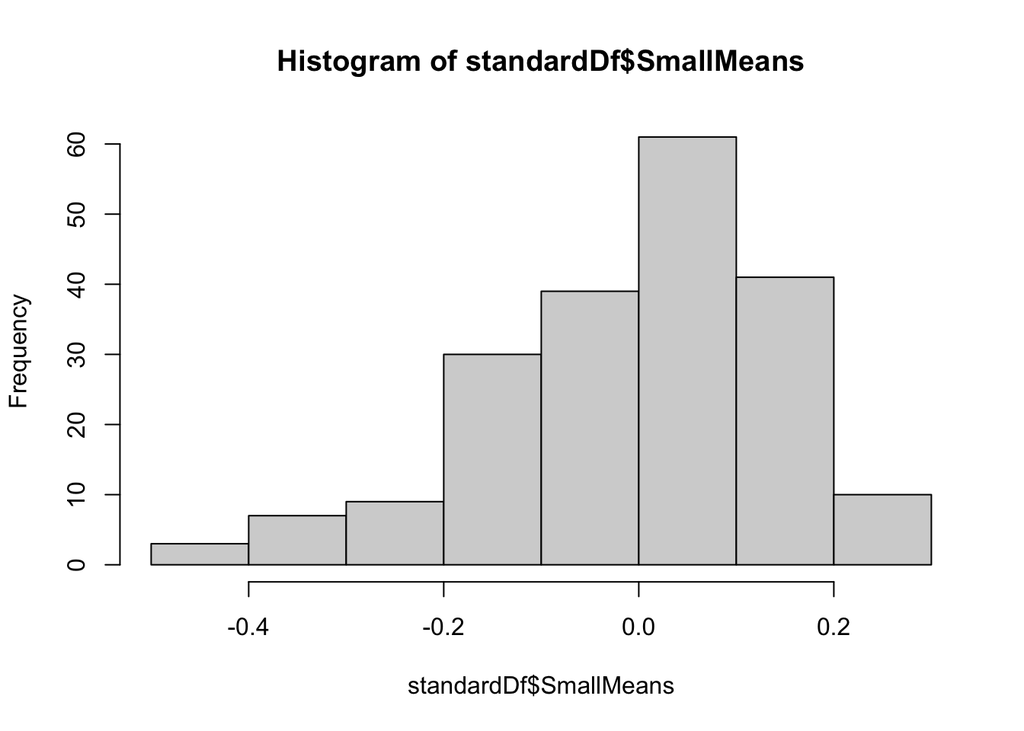

```r
hist(standardDf$SmallMeans)
```

### Correlation

```r
#get correlation for every measure against each other.
largeSmallResults <- correlation(standardDf)
largeSmallResults
```

```
## # Correlation Matrix (pearson-method)
##
## Parameter1     |     Parameter2 |        r |         95% CI |        t |  df |         p
## ----------------------------------------------------------------------------------------
## mrtCorr        |          mrtRT |    -0.34 | [-0.46, -0.20] |    -4.88 | 185 | < .001***
## mrtCorr        |      paperFold |     0.46 | [ 0.33,  0.57] |     6.81 | 172 | < .001***
## mrtCorr        |         ravens |     0.53 | [ 0.42,  0.63] |     8.55 | 183 | < .001***
## mrtCorr        |          route |     0.12 | [-0.05,  0.28] |     1.41 | 139 | > .999
## mrtCorr        |       objectas |     0.39 | [ 0.26,  0.51] |     5.73 | 179 | < .001***
## mrtCorr        |   DSP_combined |     0.32 | [ 0.18,  0.46] |     4.26 | 155 | 0.004**
## mrtCorr        |  maze_combined |     0.10 | [-0.06,  0.25] |     1.22 | 154 | > .999
## mrtCorr        |  SILC_combined |     0.32 | [ 0.16,  0.47] |     3.93 | 132 | 0.016*
## mrtCorr        |     LargeMeans |     0.28 | [ 0.14,  0.41] |     3.87 | 175 | 0.018*
## mrtCorr        |     SmallMeans |     0.64 | [ 0.55,  0.72] |    11.33 | 185 | < .001***
## mrtCorr        | LargeDeskMeans |     0.21 | [ 0.07,  0.35] |     2.84 | 168 | 0.463
## mrtCorr        |   LargeVRMeans |     0.25 | [ 0.10,  0.39] |     3.27 | 161 | 0.129
## mrtCorr        |            nav |     0.04 | [-0.11,  0.19] |     0.52 | 172 | > .999
## mrtCorr        |           game |     0.27 | [ 0.13,  0.40] |     3.71 | 172 | 0.031*
## mrtCorr        |          creat | 3.09e-03 | [-0.15,  0.15] |     0.04 | 172 | > .999
## mrtCorr        |            fit |     0.02 | [-0.13,  0.17] |     0.26 | 172 | > .999
## mrtCorr        |           tech |     0.26 | [ 0.11,  0.39] |     3.51 | 172 | 0.062
## mrtCorr        |            vge |     0.22 | [ 0.07,  0.35] |     2.93 | 175 | 0.357
## mrtRT          |      paperFold | 9.01e-03 | [-0.14,  0.16] |     0.12 | 172 | > .999
## mrtRT          |         ravens |    -0.01 | [-0.16,  0.13] |    -0.19 | 183 | > .999
## mrtRT          |          route |     0.08 | [-0.09,  0.24] |     0.90 | 139 | > .999
## mrtRT          |       objectas |    -0.13 | [-0.27,  0.02] |    -1.72 | 179 | > .999
## mrtRT          |   DSP_combined | 4.65e-04 | [-0.16,  0.16] | 5.79e-03 | 155 | > .999
## mrtRT          |  maze_combined |     0.05 | [-0.11,  0.20] |     0.59 | 154 | > .999
## mrtRT          |  SILC_combined |     0.09 | [-0.08,  0.26] |     1.03 | 132 | > .999
## mrtRT          |     LargeMeans |     0.05 | [-0.10,  0.20] |     0.69 | 175 | > .999
## mrtRT          |     SmallMeans |     0.24 | [ 0.10,  0.37] |     3.40 | 185 | 0.086
## mrtRT          | LargeDeskMeans |     0.04 | [-0.11,  0.19] |     0.48 | 168 | > .999
## mrtRT          |   LargeVRMeans |     0.06 | [-0.10,  0.21] |     0.74 | 161 | > .999
## mrtRT          |            nav |     0.15 | [ 0.00,  0.29] |     2.00 | 172 | > .999
## mrtRT          |           game |     0.09 | [-0.06,  0.23] |     1.16 | 172 | > .999
## mrtRT          |          creat |     0.08 | [-0.07,  0.23] |     1.08 | 172 | > .999
## mrtRT          |            fit |     0.07 | [-0.08,  0.22] |     0.91 | 172 | > .999
## mrtRT          |           tech |    -0.03 | [-0.18,  0.12] |    -0.37 | 172 | > .999
## mrtRT          |            vge |     0.08 | [-0.07,  0.22] |     1.00 | 175 | > .999
## paperFold      |         ravens |     0.56 | [ 0.45,  0.65] |     9.13 | 185 | < .001***
```

[output cut: 123 more lines]

```
## nav            |           tech |     0.40 | [ 0.27,  0.52] |     5.87 | 176 | < .001***
## nav            |            vge |     0.13 | [-0.02,  0.28] |     1.76 | 169 | > .999
## game           |          creat |     0.20 | [ 0.06,  0.34] |     2.74 | 176 | 0.576
## game           |            fit |     0.38 | [ 0.25,  0.50] |     5.46 | 176 | < .001***
## game           |           tech |     0.35 | [ 0.21,  0.47] |     4.91 | 176 | < .001***
## game           |            vge |     0.72 | [ 0.63,  0.78] |    13.31 | 169 | < .001***
## creat          |            fit |     0.50 | [ 0.38,  0.60] |     7.69 | 176 | < .001***
## creat          |           tech |     0.37 | [ 0.24,  0.49] |     5.31 | 176 | < .001***
## creat          |            vge |     0.06 | [-0.09,  0.21] |     0.78 | 169 | > .999
## fit            |           tech |     0.35 | [ 0.21,  0.47] |     4.97 | 176 | < .001***
## fit            |            vge |     0.10 | [-0.05,  0.25] |     1.33 | 169 | > .999
## tech           |            vge |     0.13 | [-0.02,  0.28] |     1.77 | 169 | > .999
##
## p-value adjustment method: Holm (1979)
## Observations: 106-198
```